# Customer Salary Prediction

- Don’t remove

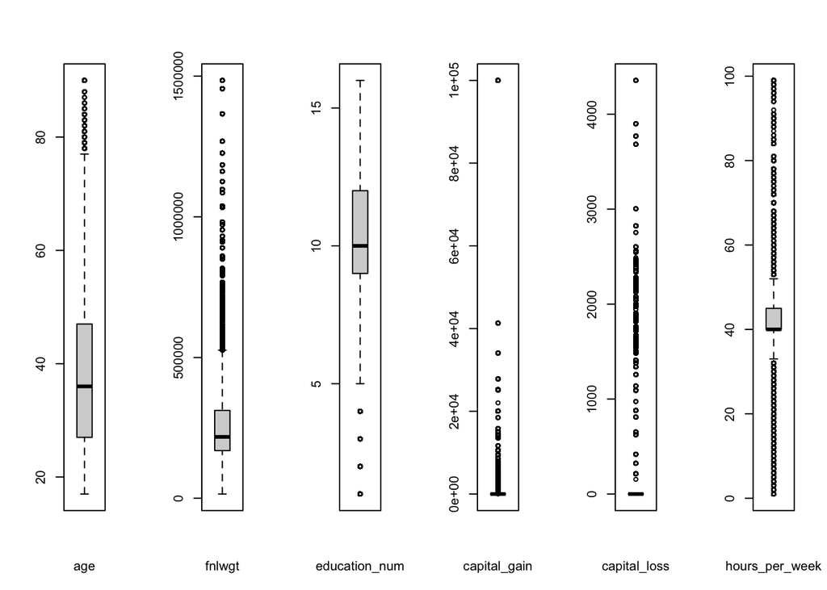

```r
numeric_cols = names(numeric_df)

par(mfrow = c(1, length(numeric_cols)))
for (i in numeric_cols){
  boxplot(
    df[i],
    xlab=c(i),
    coef = 1
    )
}
```

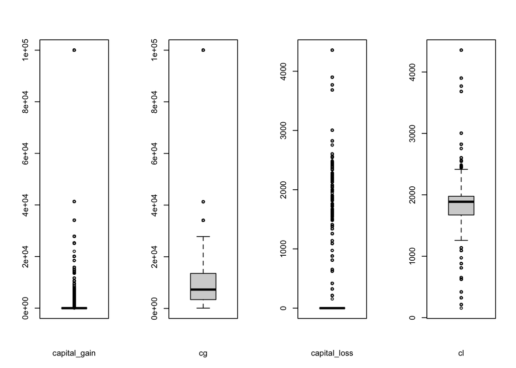

```r
#make duplicate column for capital_gain
df$cg = df$capital_gain
#set zero to NA
df$cg[df$cg==0]<-NA

#make duplicate column for capital_loss
df$cl = df$capital_loss
#set zero to NA
df$cl[df$cl==0]<-NA


outlier_plot_cols = c('capital_gain','cg','capital_loss','cl')

par(mfrow = c(1, length(outlier_plot_cols)))
for (i in outlier_plot_cols){
  boxplot(
    df[i],
    xlab=c(i),
    coef = 1
    )
}
```

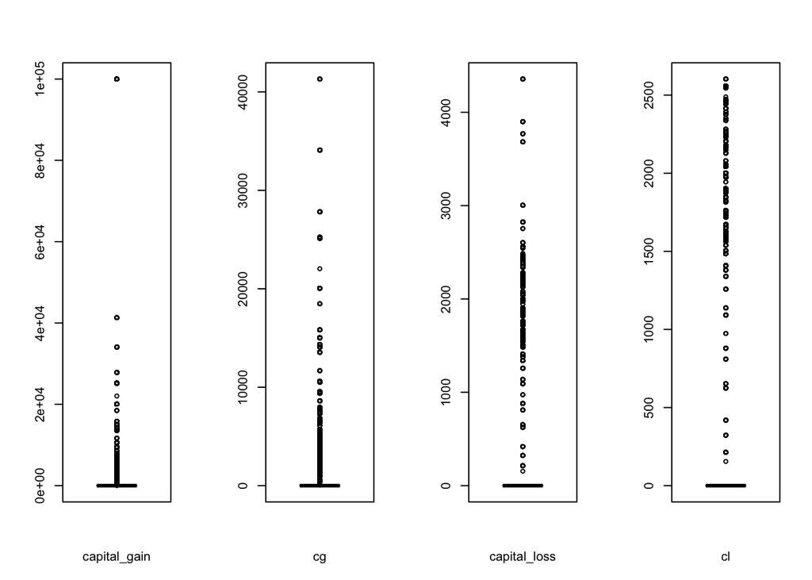

```r
outlier_cols = c('cg','cl')

#remove outliers
#df[outlier_cols] <- data.frame(lapply( df[outlier_cols], function(x) {
# ifelse(x %in% boxplot.stats(x)$out, NA, x) }))


df[outlier_cols] <- data.frame( lapply(df[outlier_cols],
  function(x, na.rm = TRUE)
    {ifelse( (x < 0) | x > (mean(x, na.rm = TRUE) + 2 *sd(x, na.rm = TRUE)), NA, x) }))


#add zeroes back into duplicate col
df$cg [df$capital_gain==0]<-0
df$cl [df$capital_loss==0]<-0

outlier_plot_cols = c('capital_gain','cg','capital_loss','cl')

par(mfrow = c(1, length(outlier_plot_cols)))
for (i in outlier_plot_cols){
  boxplot(
    df[i],
    xlab=c(i),
    coef = 1
    )
}
```

Plot shows before vs after having removed zeroes, then removed outliers, and added zeroes back.

EDA / Sanity check :

Many values are marked with “?” – so, where are they? and set them to NA.

Remove “?”s or no?

Show count of unique categorical values and NA coun

```r
cat_stats <- data.frame(
            unique = sapply(df, n_distinct),
            NA_count = sapply(df, function(x) sum(is.na(x))),
            data_type = sapply(df, class)
            ) %>%
    filter(data_type == 'character') %>%
    select(unique, NA_count) %>%
    arrange(unique)

cat_stats
```

```
##                unique NA_count
## sex                 2        0
## salary              2        0
## race                5        0
## relationship        6        0
## marital_status      7        0
## workclass           9        0
## occupation         15        0
## education          16        0
## native_country     42        0
```

Any strange number of unique values?

- Martital status should be reduced to married vs not married.
- Education can be reduced to lower, middle, high school, some college, college, grad school.
- Any others? Workclass?

```r
df = df %>% mutate(
  married = case_when(
    marital_status == ' Divorced' ~ "N",
    marital_status == ' Married-AF-spouse' ~ "Y",
    marital_status == ' Married-civ-spouse' ~ "Y",
    marital_status == ' Married-spouse-absent' ~ "Y",
    marital_status == ' Never-married' ~ "N",
    marital_status == ' Separated' ~ "Y",
    marital_status == ' Widowed' ~ "N"
  )
)


df = df %>% mutate(
  education_simple = case_when(
    education_num <=4 ~ "Below High School",
    education_num >=5 & education_num <=8 ~ "Some High School",
    education_num ==9 ~ "High School",
    education_num ==10 ~ "Some College",
    education_num >=11 & education_num <=13 ~ "College",
    education_num >=14 ~ "Masters or Above"

  )
)
```

Impute the missing values.

Replaced NAs with the mean.

```r
outlier_cols = c('cg','cl')

df[outlier_cols] <- data.frame(lapply(df[outlier_cols], function(x) {
  ifelse(is.na(x), mean(x, na.rm = TRUE), x) }))


# overwrite capital_gain and capital_loss with cg and gl, then drop cg and cl
df$capital_gain = df$cg
df$capital_loss = df$cl
df = select(df, -cg, -cl)
```

EDA, continued

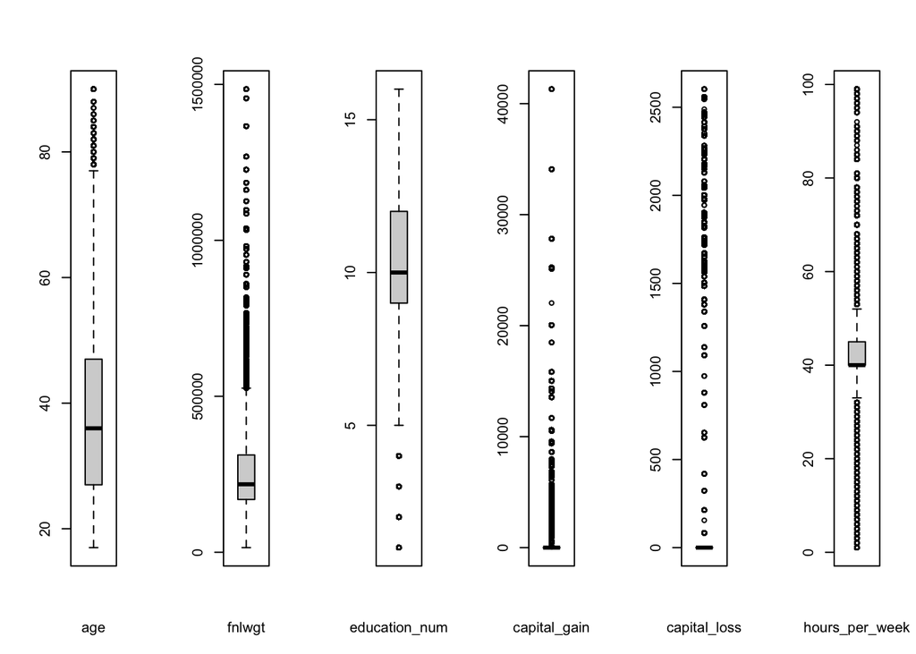

```r
numeric_cols = names(numeric_df)

par(mfrow = c(1, length(numeric_cols)))
for (i in numeric_cols){
  boxplot(
    df[i],
    xlab=c(i),
    coef = 1
    )}
```

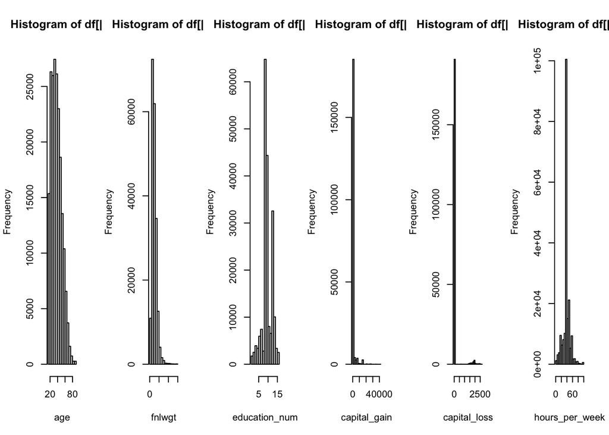

```r
numeric_cols = names(numeric_df)

par(mfrow = c(1, length(numeric_cols)))
for (i in numeric_cols){
  hist(
    df[[i]],
    xlab=c(i)
    )
}
```

```r
data.frame(type=sapply(df,class)) %>% filter(type== 'character')
```

```
##                       type
## workclass        character
## education        character
## marital_status   character
## occupation       character
## relationship     character
## race             character
## sex              character
## native_country   character
## salary           character
## married          character
## education_simple character
```

```r
#data.frame(table(df$education_simple))
```

Convert All Categorical Columns to Factors

```r
#df$capital_gain = log( df$capital_gain )

df$workclass = factor(df$workclass)

df$education = factor(df$education, levels=
c(' Preschool' ,' 1st-4th' ,' 5th-6th' ,' 7th-8th' ,' 9th' ,' 10th' ,' 11th' ,' 12th' ,' HS-grad' ,' Some-college' ,' Assoc-voc' ,' Assoc-acdm' ,' Bachelors' ,' Masters' ,' Prof-school' ,' Doctorate') )

df$education_simple = factor(df$education_simple, levels=
c( 'Below High School','Some High School','High School','Some College','College','Masters or Above') )

df$marital_status = factor(df$marital_status)
df$occupation = factor(df$occupation)
df$relationship = factor(df$relationship)
df$race = factor(df$race)
df$sex = factor(df$sex)
df$native_country = factor(df$native_country)

df [df$salary==' >50K' , 'y'] = 1
df [df$salary==' <=50K' , 'y'] = 0
df$y = factor(df$y)

df$salary = factor(df$salary, levels = c(' <=50K',' >50K'))

df$married = factor(df$married)

#head(df$salary)
```

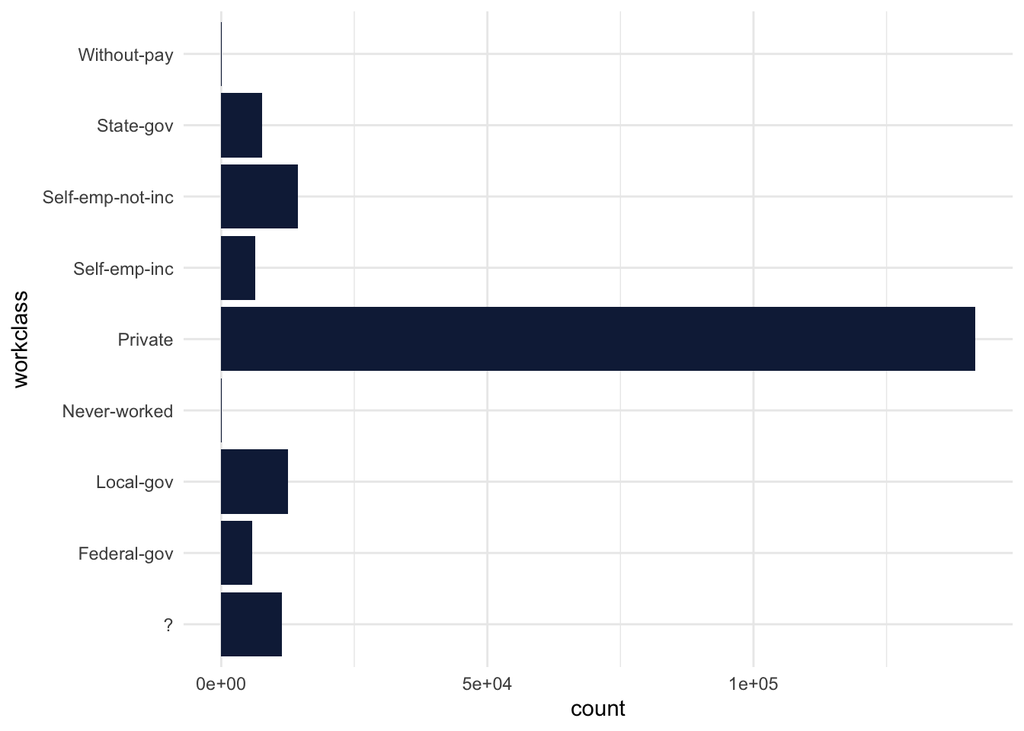

```r
ggplot(df) +
 aes_string(x = "workclass") +
 geom_bar(fill = "#112446") +
 coord_flip() +
 theme_minimal()
```

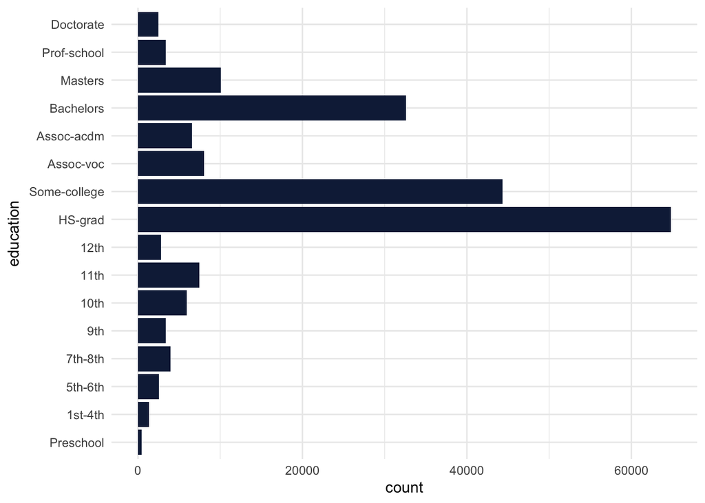

```r
ggplot(df) +
 aes_string(x = "education") +
 geom_bar(fill = "#112446") +
 coord_flip() +
 theme_minimal()
```

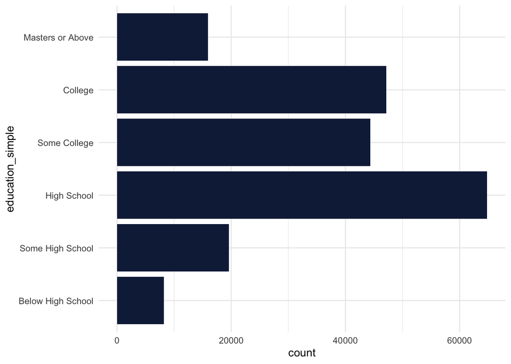

```r
ggplot(df) +
 aes_string(x = "education_simple") +
 geom_bar(fill = "#112446") +
 coord_flip() +
 theme_minimal()
```

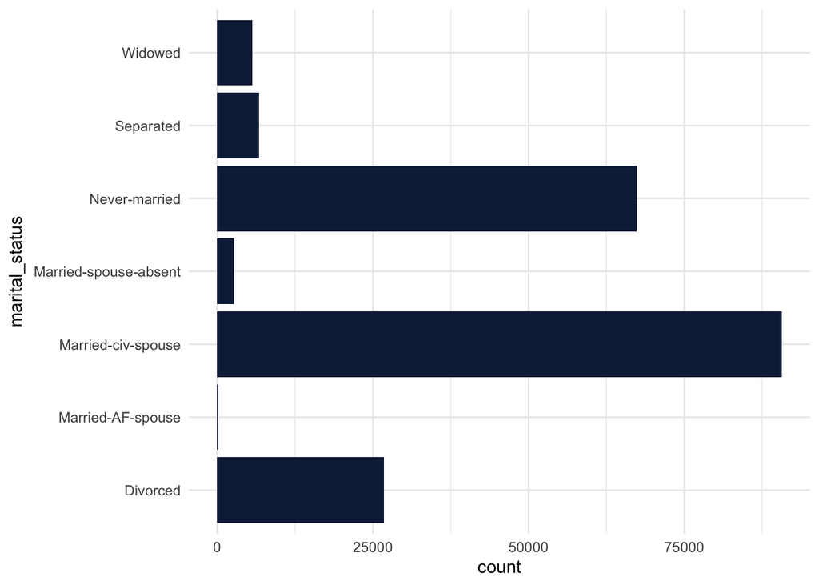

```r
ggplot(df) +
 aes_string(x = "marital_status") +
 geom_bar(fill = "#112446") +
 coord_flip() +
 theme_minimal()
```

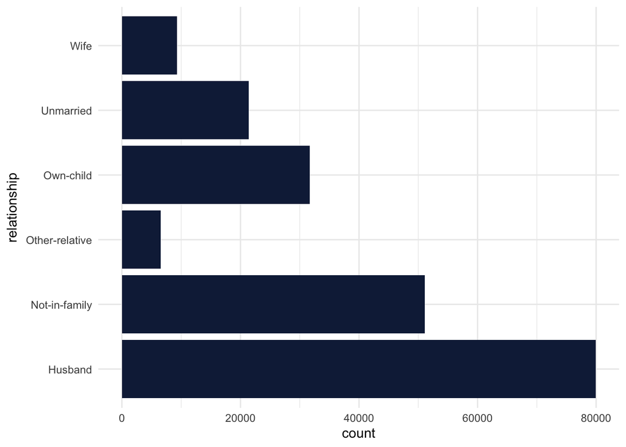

```r
ggplot(df) +
 aes_string(x = "relationship") +
 geom_bar(fill = "#112446") +
 coord_flip() +
 theme_minimal()
```

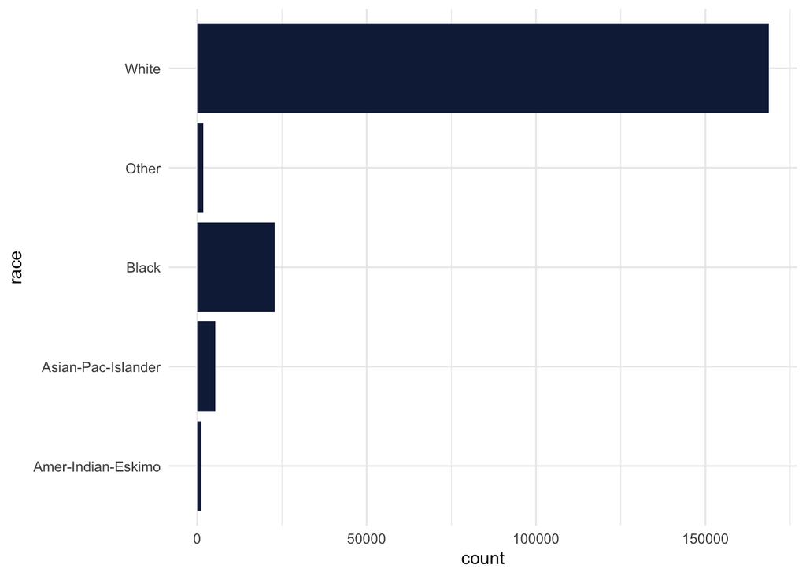

```r
ggplot(df) +
 aes_string(x = "race") +
 geom_bar(fill = "#112446") +
 coord_flip() +
 theme_minimal()
```

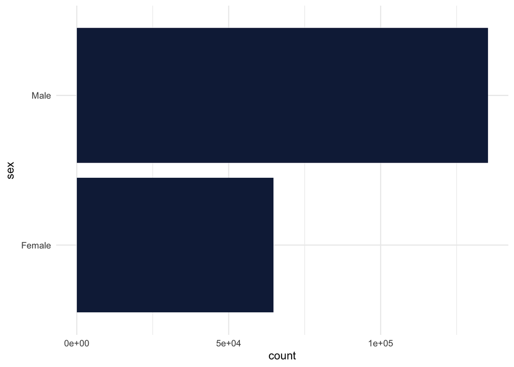

```r
ggplot(df) +
 aes_string(x = "sex") +
 geom_bar(fill = "#112446") +
 coord_flip() +
 theme_minimal()
```

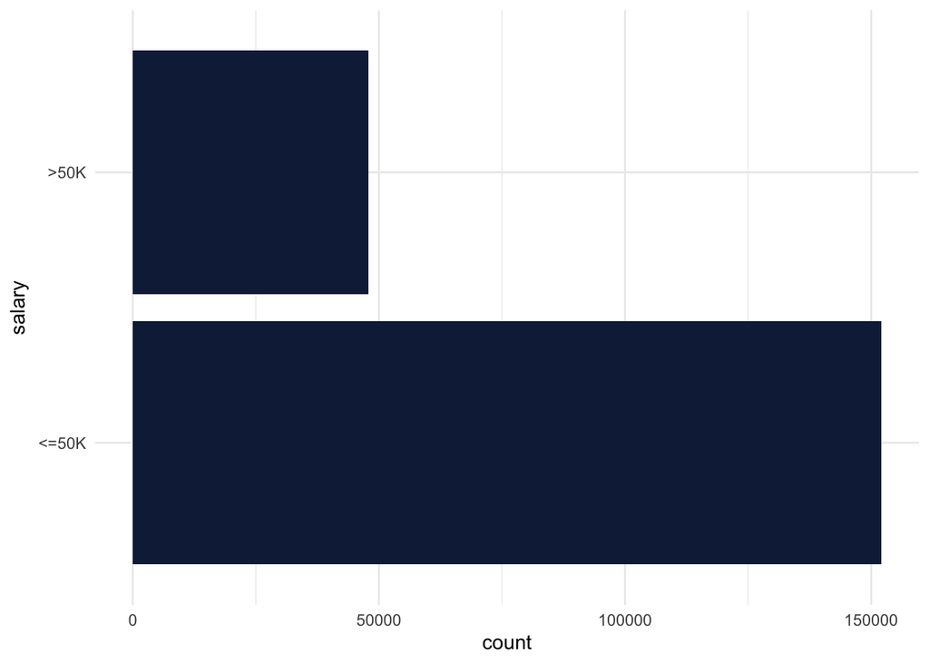

```r
ggplot(df) +
 aes_string(x = "salary") +
 geom_bar(fill = "#112446") +
 coord_flip() +
 theme_minimal()
```

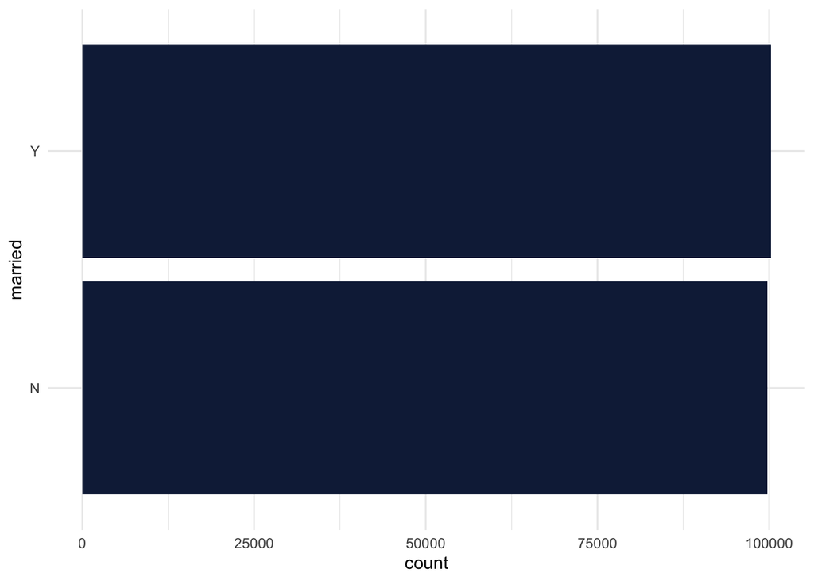

```r
ggplot(df) +
 aes_string(x = "married") +
 geom_bar(fill = "#112446") +
 coord_flip() +
 theme_minimal()
```

```r
# if you wish to do the model with another software, make sure to use this datat that has been formatted

#write.csv(df,"data/adult_sampled_formatted_pre_model.csv", row.names = FALSE)
```

# Models

Split train and test data

```r
training.rows <- sample(1:nrow(df),size=0.7*nrow(df))
train_data <- df[training.rows,]
test_data <- df[-training.rows,]


nrow(df)
```

```
## [1] 200000
```

```r
print(nrow(train_data) )
```

```
## [1] 140000
```

```r
print(nrow(test_data) )
```

```
## [1] 60000
```

```r
#this is where we will store the metrics for each model
model_stats = data.frame(metric = c("Accuracy","True Positive Rate","False Positive Rate","Specificity","Precision","Prevalence"))
```

```r
#our variables

#data.frame(type=sapply(df,class))
c(names(df))
```

```
##  [1] "age"              "workclass"        "fnlwgt"           "education"
##  [5] "education_num"    "marital_status"   "occupation"       "relationship"
##  [9] "race"             "sex"              "capital_gain"     "capital_loss"
## [13] "hours_per_week"   "native_country"   "salary"           "married"
## [17] "education_simple" "y"
```

Naïve Bayes Model

Which variables are important?

Let’s start with:

age race native_country

married relationship

workclass occupation hours_per_week

education education_simple

capital_gain capital_loss

age+race+native_country+married+relationship+workclass+occupation+hours_per_week+education_simple+capital_gain+capital_loss

```r
NBmodel <- naive_bayes(salary ~ age+race+married+relationship+workclass+occupation+hours_per_week+education_simple+capital_gain+capital_loss,
                     data = train_data)
summary(NBmodel)
```

```
##
## ================================== Naive Bayes ==================================
##
## - Call: naive_bayes.formula(formula = salary ~ age + race + married +      relationship + workclass + occupation + hours_per_week +      education_simple + capital_gain + capital_loss, data = train_data)
## - Laplace: 0
## - Classes: 2
## - Samples: 140000
## - Features: 10
## - Conditional distributions:
##     - Bernoulli: 1
##     - Categorical: 5
##     - Gaussian: 4
## - Prior probabilities:
##     -  <=50K: 0.761
##     -  >50K: 0.239
##
## ---------------------------------------------------------------------------------
```

Score the validation data (predict) using the model. Produce a confusion table and an ROC curve for the scored validation data.

```r
#classification matrix
predNB = predict(NBmodel, test_data, type="prob")[,2] #This is the probability that the score is a "good score"

pred = predNB
pred[pred>=.5] = 1
pred[pred!=1] = 0

classMatrix = table(pred,test_data$salary) #first variable is by row, the second is by column
print("Classification Matrix:")
```

```
## [1] "Classification Matrix:"
```

```r
print(classMatrix)
```

```
##
## pred  <=50K  >50K
##    0  42194  6791
##    1   3345  7670
```

ROC Curve

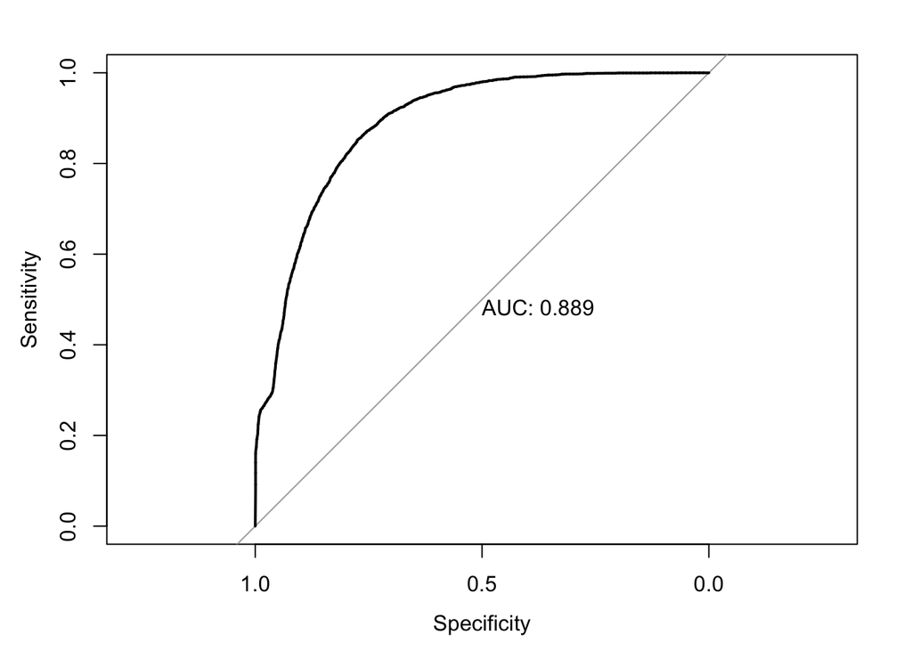

```r
roc_curve = roc(test_data$salary,predNB,plot = TRUE, print.auc = TRUE)
```

```r
AUC<- auc(roc_curve)
```

Calculate: accuracy, misclassification rate, true positive rate, false positive rate, specificity, precision, and prevalence.

```r
#Accuracy score?
print("Accuracy:")
```

```
## [1] "Accuracy:"
```

```r
accuracy = sum(diag(classMatrix))/sum(classMatrix)
print(accuracy)
```

```
## [1] 0.8310667
```

```r
cat("\n")
```

```r
print("Misclassification Rate")
```

```
## [1] "Misclassification Rate"
```

```r
print(1-accuracy)
```

```
## [1] 0.1689333
```

```r
cat("\n")
```

```r
true_negative<-classMatrix[1,1]
false_positive<-classMatrix[2,1]
true_positive<-classMatrix[2,2]
false_negative<-classMatrix[1,2]


print("True Positive Rate")
```

```
## [1] "True Positive Rate"
```

```r
true_positive_rate = (true_positive)/ (true_positive + false_negative)
print(true_positive_rate)
```

```
## [1] 0.5303921
```

```r
cat("\n")
```

```r
print("False Positive Rate")
```

```
## [1] "False Positive Rate"
```

```r
false_positive_rate = (false_positive)/ (false_positive + true_negative)
print(false_positive_rate)
```

```
## [1] 0.07345352
```

```r
cat("\n")
```

```r
print("Specificity:")
```

```
## [1] "Specificity:"
```

```r
specificity<-true_negative/(true_negative+false_negative)
print(specificity)
```

```
## [1] 0.8613657
```

```r
cat("\n")
```

```r
print("Precision:")
```

```
## [1] "Precision:"
```

```r
precision<-true_positive/(true_positive+false_positive)
print(precision)
```

```
## [1] 0.6963232
```

```r
cat("\n")
```

```r
print("Prevalence:")
```

```
## [1] "Prevalence:"
```

```r
prevalence = (true_positive + false_negative)/(true_negative+false_positive+true_positive+false_negative)
print(prevalence)
```

```
## [1] 0.2410167
```

```r
#add to model_stats
model_stats$naiveBayes = c(accuracy, true_positive_rate, false_positive_rate, specificity, precision, 1)
model_stats$naiveBayes = round(model_stats$naiveBayes,2)
```

Logit Model

```r
LRmodel = glm(salary~
            age+race+married+relationship+workclass+occupation+hours_per_week+education_simple+capital_gain+capital_loss,
            train_data, family = "binomial")

summary(LRmodel)
```

```
##
## Call:
## glm(formula = salary ~ age + race + married + relationship +
##     workclass + occupation + hours_per_week + education_simple +
##     capital_gain + capital_loss, family = "binomial", data = train_data)
##
## Coefficients: (1 not defined because of singularities)
##                                    Estimate Std. Error z value Pr(>|z|)
## (Intercept)                      -7.413e+00  1.759e-01 -42.157  < 2e-16 ***
## age                               2.777e-02  7.681e-04  36.154  < 2e-16 ***
## race Asian-Pac-Islander           6.838e-01  1.419e-01   4.818 1.45e-06 ***
## race Black                        6.068e-01  1.361e-01   4.460 8.19e-06 ***
## race Other                        3.596e-01  1.781e-01   2.019 0.043466 *
## race White                        7.777e-01  1.330e-01   5.846 5.02e-09 ***
## marriedY                          6.441e-01  5.165e-02  12.471  < 2e-16 ***
## relationship Not-in-family       -1.590e+00  5.212e-02 -30.497  < 2e-16 ***
## relationship Other-relative      -1.951e+00  9.739e-02 -20.029  < 2e-16 ***
## relationship Own-child           -2.689e+00  7.958e-02 -33.789  < 2e-16 ***
## relationship Unmarried           -1.954e+00  5.751e-02 -33.975  < 2e-16 ***
## relationship Wife                 5.534e-01  3.346e-02  16.538  < 2e-16 ***
## workclass Federal-gov             9.712e-01  7.384e-02  13.154  < 2e-16 ***
## workclass Local-gov               3.332e-01  6.697e-02   4.976 6.48e-07 ***
## workclass Never-worked           -9.380e+00  6.863e+01  -0.137 0.891288
## workclass Private                 5.014e-01  5.995e-02   8.364  < 2e-16 ***
## workclass Self-emp-inc            7.359e-01  7.265e-02  10.128  < 2e-16 ***
## workclass Self-emp-not-inc        1.722e-01  6.586e-02   2.614 0.008944 **
## workclass State-gov               2.485e-01  7.258e-02   3.424 0.000617 ***
## workclass Without-pay            -1.097e+01  5.624e+01  -0.195 0.845288
## occupation Adm-clerical           8.640e-02  4.760e-02   1.815 0.069518 .
## occupation Armed-Forces          -2.531e-01  6.929e-01  -0.365 0.714929
## occupation Craft-repair           2.645e-01  4.149e-02   6.375 1.83e-10 ***
## occupation Exec-managerial        9.018e-01  4.247e-02  21.232  < 2e-16 ***
## occupation Farming-fishing       -1.270e+00  7.925e-02 -16.031  < 2e-16 ***
## occupation Handlers-cleaners     -5.548e-01  7.062e-02  -7.856 3.97e-15 ***
## occupation Machine-op-inspct     -1.521e-01  5.125e-02  -2.969 0.002992 **
## occupation Other-service         -7.205e-01  5.983e-02 -12.042  < 2e-16 ***
## occupation Priv-house-serv       -3.775e+00  8.854e-01  -4.264 2.01e-05 ***
## occupation Prof-specialty         7.945e-01  4.498e-02  17.662  < 2e-16 ***
## occupation Protective-serv        8.161e-01  6.256e-02  13.044  < 2e-16 ***
## occupation Sales                  5.142e-01  4.380e-02  11.740  < 2e-16 ***
## occupation Tech-support           8.583e-01  5.737e-02  14.962  < 2e-16 ***
## occupation Transport-moving              NA         NA      NA       NA
## hours_per_week                    3.487e-02  8.048e-04  43.331  < 2e-16 ***
## education_simpleSome High School  7.923e-01  8.424e-02   9.405  < 2e-16 ***
## education_simpleHigh School       1.622e+00  7.476e-02  21.693  < 2e-16 ***
## education_simpleSome College      2.023e+00  7.585e-02  26.674  < 2e-16 ***
## education_simpleCollege           2.565e+00  7.575e-02  33.860  < 2e-16 ***
## education_simpleMasters or Above  3.193e+00  7.967e-02  40.081  < 2e-16 ***
## capital_gain                      3.293e-04  5.024e-06  65.535  < 2e-16 ***
## capital_loss                      6.253e-04  1.890e-05  33.078  < 2e-16 ***
## ---
## Signif. codes:  0 '***' 0.001 '**' 0.01 '*' 0.05 '.' 0.1 ' ' 1
##
## (Dispersion parameter for binomial family taken to be 1)
##
##     Null deviance: 153970  on 139999  degrees of freedom
## Residual deviance:  88999  on 139959  degrees of freedom
## AIC: 89081
##
## Number of Fisher Scoring iterations: 12
```

Which variables can we reject the null hypothesis that their coefficients equal zero?

```r
varImp(LRmodel) %>% arrange(-Overall)
```

```
##                                     Overall
## capital_gain                     65.5345925
## hours_per_week                   43.3314474
## education_simpleMasters or Above 40.0812663
## age                              36.1536095
## relationship Unmarried           33.9748220
## education_simpleCollege          33.8595449
## relationship Own-child           33.7888527
## capital_loss                     33.0781061
## relationship Not-in-family       30.4968771
## education_simpleSome College     26.6738637
## education_simpleHigh School      21.6932622
## occupation Exec-managerial       21.2315053
## relationship Other-relative      20.0285406
## occupation Prof-specialty        17.6615577
## relationship Wife                16.5376407
## occupation Farming-fishing       16.0311257
## occupation Tech-support          14.9622017
## workclass Federal-gov            13.1537428
## occupation Protective-serv       13.0440601
## marriedY                         12.4713140
## occupation Other-service         12.0423781
## occupation Sales                 11.7397202
## workclass Self-emp-inc           10.1282295
## education_simpleSome High School  9.4051980
## workclass Private                 8.3638368
## occupation Handlers-cleaners      7.8558743
## occupation Craft-repair           6.3748255
## race White                        5.8463932
## workclass Local-gov               4.9762693
## race Asian-Pac-Islander           4.8176246
## race Black                        4.4600695
## occupation Priv-house-serv        4.2638833
## workclass State-gov               3.4239576
## occupation Machine-op-inspct      2.9685299
## workclass Self-emp-not-inc        2.6141860
## race Other                        2.0192016
## occupation Adm-clerical           1.8150413
## occupation Armed-Forces           0.3652439
## workclass Without-pay             0.1951341
## workclass Never-worked            0.1366748
```

Score the validation data (predict) using the logit model.

```r
#classification matrix
predLR = predict(LRmodel,test_data,type="response") #This is the probability that the score is a "good score"
pred = predLR
pred[pred>=.5] = 1
pred[pred!=1] = 0

classMatrix = table(pred,test_data$salary) #first variable is by row, the second is by column
print("Classification Matrix:")
```

```
## [1] "Classification Matrix:"
```

```r
print(classMatrix)
```

```
##
## pred  <=50K  >50K
##    0  42225  5512
##    1   3314  8949
```

ROC Curve

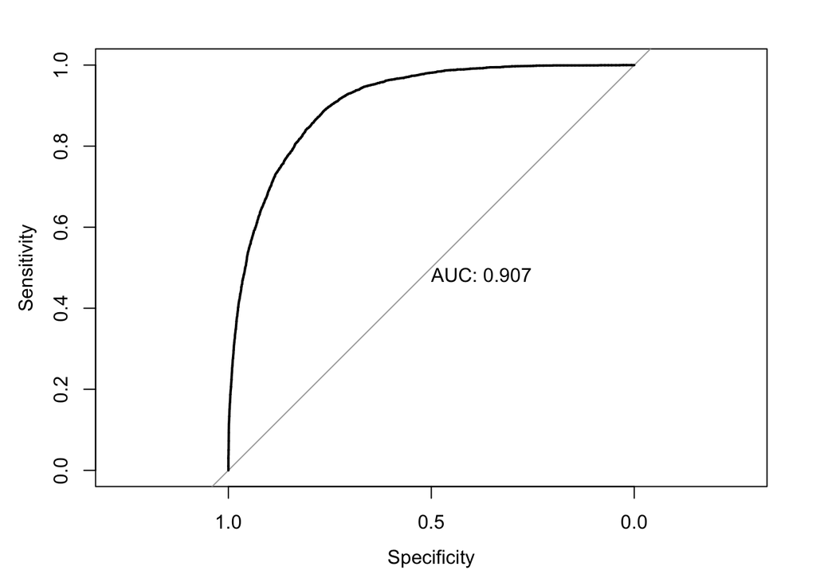

```r
roc_curve = roc(test_data$salary,predLR,plot = TRUE, print.auc = TRUE)
```

```r
AUC<- auc(roc_curve)
```

Calculate: accuracy, misclassification rate, true positive rate, false positive rate, specificity, precision, and prevalence.

```r
#Accuracy score?
print("Accuracy:")
```

```
## [1] "Accuracy:"
```

```r
accuracy = sum(diag(classMatrix))/sum(classMatrix)
print(accuracy)
```

```
## [1] 0.8529
```

```r
cat("\n")
```

```r
print("Misclassification Rate")
```

```
## [1] "Misclassification Rate"
```

```r
print(1-accuracy)
```

```
## [1] 0.1471
```

```r
cat("\n")
```

```r
true_negative<-classMatrix[1,1]
false_positive<-classMatrix[2,1]
true_positive<-classMatrix[2,2]
false_negative<-classMatrix[1,2]


print("True Positive Rate")
```

```
## [1] "True Positive Rate"
```

```r
true_positive_rate = (true_positive)/ (true_positive + false_negative)
print(true_positive_rate)
```

```
## [1] 0.6188369
```

```r
cat("\n")
```

```r
print("False Positive Rate")
```

```
## [1] "False Positive Rate"
```

```r
false_positive_rate = (false_positive)/ (false_positive + true_negative)
print(false_positive_rate)
```

```
## [1] 0.07277279
```

```r
cat("\n")
```

```r
print("Specificity:")
```

```
## [1] "Specificity:"
```

```r
specificity<-true_negative/(true_negative+false_negative)
print(specificity)
```

```
## [1] 0.884534
```

```r
cat("\n")
```

```r
print("Precision:")
```

```
## [1] "Precision:"
```

```r
precision<-true_positive/(true_positive+false_positive)
print(precision)
```

```
## [1] 0.7297562
```

```r
cat("\n")
```

```r
print("Prevalence:")
```

```
## [1] "Prevalence:"
```

```r
prevalence = (true_positive + false_negative)/(true_negative+false_positive+true_positive+false_negative)
print(prevalence)
```

```
## [1] 0.2410167
```

```r
#add to model_stats
model_stats$Logistic = c(accuracy, true_positive_rate, false_positive_rate, specificity, precision, 1)
model_stats$Logistic = round(model_stats$Logistic,2)
```

Tree Model (CART)

```r
adultTree = rpart(y ~ age+race+married+relationship+workclass+occupation+hours_per_week+education_simple+capital_gain+capital_loss, data=train_data, method="class", minbucket = 25)

#summary(adultTree)
```

Variable/feature importance

```r
varImp(adultTree) %>% arrange(-Overall)
```

```
##                      Overall
## capital_gain     13934.91666
## education_simple 11164.50423
## relationship     10419.02010
## occupation       10270.95033
## married           8558.07969
## capital_loss      2241.66083
## hours_per_week    1858.99375
## age               1600.10235
## workclass           85.70589
## race                 0.00000
```

```r
write.csv(varImp(adultTree) %>% arrange(-Overall), 'data/variable_importance.csv')
```

Plot of the decision tree.

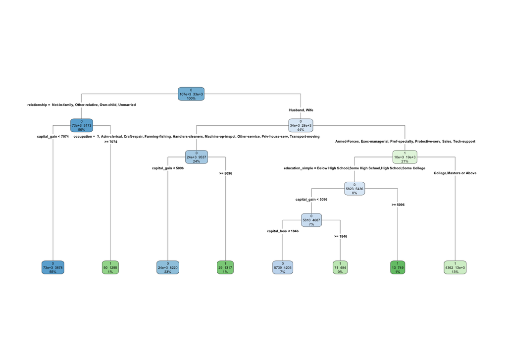

```r
rpart.plot(adultTree, type=4, extra=101, fallen.leaves = TRUE)
```

Score the validation data (predict) using the CART model, produce a confusion table and an ROC curve.

```r
PredictCART = predict(adultTree, newdata= test_data,type='prob')[,2]

pred = PredictCART
pred[pred>=.5] = 1
pred[pred!=1] = 0

classMatrix = table(pred,test_data$salary) #first variable is by row, the second is by column
print("Classification Matrix:")
```

```
## [1] "Classification Matrix:"
```

```r
print(classMatrix)
```

```
##
## pred  <=50K  >50K
##    0  43604  7013
##    1   1935  7448
```

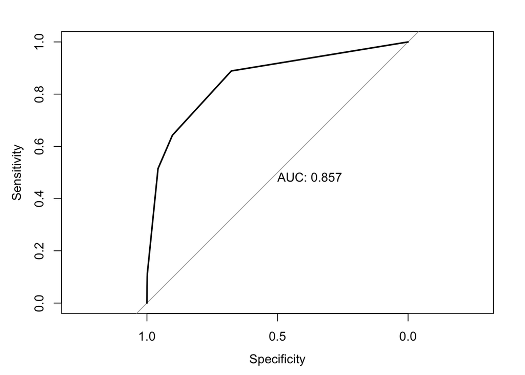

```r
roc_curve = roc(test_data$salary,PredictCART,plot = TRUE, print.auc = TRUE)
```

```r
AUC<- auc(roc_curve)
```

Calculate: accuracy, misclassification rate, true positive rate, false positive rate, specificity, precision, and prevalence.

```r
#Accuracy score?
print("Accuracy:")
```

```
## [1] "Accuracy:"
```

```r
accuracy = sum(diag(classMatrix))/sum(classMatrix)
print(accuracy)
```

```
## [1] 0.8508667
```

```r
cat("\n")
```

```r
print("Misclassification Rate")
```

```
## [1] "Misclassification Rate"
```

```r
print(1-accuracy)
```

```
## [1] 0.1491333
```

```r
cat("\n")
```

```r
true_negative<-classMatrix[1,1]
false_positive<-classMatrix[2,1]
true_positive<-classMatrix[2,2]
false_negative<-classMatrix[1,2]


print("True Positive Rate")
```

```
## [1] "True Positive Rate"
```

```r
true_positive_rate = (true_positive)/ (true_positive + false_negative)
print(true_positive_rate)
```

```
## [1] 0.5150405
```

```r
cat("\n")
```

```r
print("False Positive Rate")
```

```
## [1] "False Positive Rate"
```

```r
false_positive_rate = (false_positive)/ (false_positive + true_negative)
print(false_positive_rate)
```

```
## [1] 0.04249105
```

```r
cat("\n")
```

```r
print("Specificity:")
```

```
## [1] "Specificity:"
```

```r
specificity<-true_negative/(true_negative+false_negative)
print(specificity)
```

```
## [1] 0.8614497
```

```r
cat("\n")
```

```r
print("Precision:")
```

```
## [1] "Precision:"
```

```r
precision<-true_positive/(true_positive+false_positive)
print(precision)
```

```
## [1] 0.793776
```

```r
cat("\n")
```

```r
print("Prevalence:")
```

```
## [1] "Prevalence:"
```

```r
prevalence = (true_positive + false_negative)/(true_negative+false_positive+true_positive+false_negative)
print(prevalence)
```

```
## [1] 0.2410167
```

```r
#add to model_stats
model_stats$CART = c(accuracy, true_positive_rate, false_positive_rate, specificity, precision, 1)
model_stats$CART = round(model_stats$CART,2)
```

```r
#Random Forest
modelRF <- randomForest(salary~age+race+married+relationship+workclass+occupation+hours_per_week+education_simple+capital_gain+capital_loss, data = train_data)
```

```r
varImp(modelRF) %>% arrange(-Overall)
```

```
##                    Overall
## relationship     6446.5860
## age              5773.4336
## capital_gain     5517.8293
## occupation       5031.0385
## education_simple 4191.8906
## married          3541.9132
## hours_per_week   3472.9802
## workclass        1732.7218
## capital_loss     1682.3496
## race              837.3012
```

```r
PredRF = predict(modelRF, newdata= test_data,type='prob')[,2]
pred = PredRF

pred[pred>=.5] = 1
pred[pred!=1] = 0

classMatrix = table(pred,test_data$salary) #first variable is by row, the second is by column
print("Classification Matrix:")
```

```
## [1] "Classification Matrix:"
```

```r
print(classMatrix)
```

```
##
## pred  <=50K  >50K
##    0  44329  2109
##    1   1210 12352
```

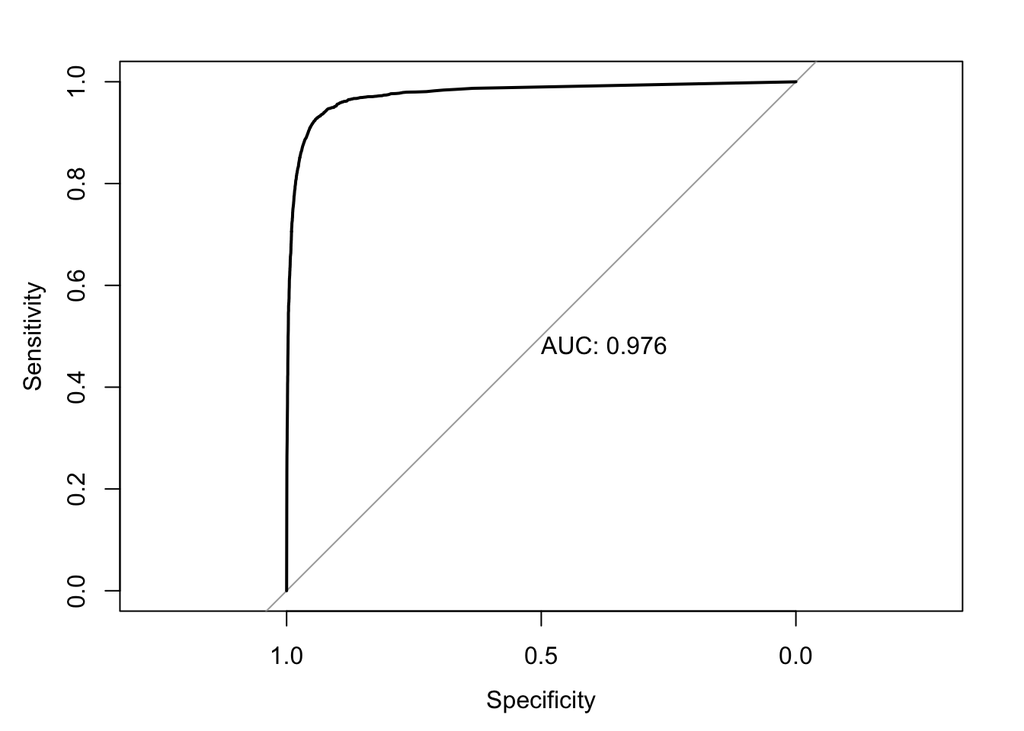

```r
roc_curve = roc(test_data$salary,PredRF,plot = TRUE, print.auc = TRUE)
```

```r
AUC<- auc(roc_curve)
```

Calculate: accuracy, misclassification rate, true positive rate, false positive rate, specificity, precision, and prevalence.

```r
#Accuracy score?
print("Accuracy:")
```

```
## [1] "Accuracy:"
```

```r
accuracy = sum(diag(classMatrix))/sum(classMatrix)
print(accuracy)
```

```
## [1] 0.9446833
```

```r
cat("\n")
```

```r
print("Misclassification Rate")
```

```
## [1] "Misclassification Rate"
```

```r
print(1-accuracy)
```

```
## [1] 0.05531667
```

```r
cat("\n")
```

```r
true_negative<-classMatrix[1,1]
false_positive<-classMatrix[2,1]
true_positive<-classMatrix[2,2]
false_negative<-classMatrix[1,2]


print("True Positive Rate")
```

```
## [1] "True Positive Rate"
```

```r
true_positive_rate = (true_positive)/ (true_positive + false_negative)
print(true_positive_rate)
```

```
## [1] 0.8541595
```

```r
cat("\n")
```

```r
print("False Positive Rate")
```

```
## [1] "False Positive Rate"
```

```r
false_positive_rate = (false_positive)/ (false_positive + true_negative)
print(false_positive_rate)
```

```
## [1] 0.02657063
```

```r
cat("\n")
```

```r
print("Specificity:")
```

```
## [1] "Specificity:"
```

```r
specificity<-true_negative/(true_negative+false_negative)
print(specificity)
```

```
## [1] 0.9545846
```

```r
cat("\n")
```

```r
print("Precision:")
```

```
## [1] "Precision:"
```

```r
precision<-true_positive/(true_positive+false_positive)
print(precision)
```

```
## [1] 0.9107801
```

```r
cat("\n")
```

```r
print("Prevalence:")
```

```
## [1] "Prevalence:"
```

```r
prevalence = (true_positive + false_negative)/(true_negative+false_positive+true_positive+false_negative)
print(prevalence)
```

```
## [1] 0.2410167
```

```r
#add to model_stats
model_stats$randomForest = c(accuracy, true_positive_rate, false_positive_rate, specificity, precision, 1)
model_stats$randomForest = round(model_stats$randomForest,2)
```

```r
write.csv(model_stats, file='data/model_stats.csv')
model_stats
```

```
##                metric naiveBayes Logistic CART randomForest
## 1            Accuracy       0.83     0.85 0.85         0.94
## 2  True Positive Rate       0.53     0.62 0.52         0.85
## 3 False Positive Rate       0.07     0.07 0.04         0.03
## 4         Specificity       0.86     0.88 0.86         0.95
## 5           Precision       0.70     0.73 0.79         0.91
## 6          Prevalence       1.00     1.00 1.00         1.00
```